# Introduction

We saw in Part A, that one could use soft thresholding to create a model that recapitulated the results from `analysis-01-dynamics`. Here we want to show that we can learn the optimal parameters of such a model.

# Setup

Import stuff and determine device we will use for computations

```python
import os
import copy
import h5py
import pandas as pd
import numpy as np
import progressbar
import torch
from torch import nn
from torch.utils.data import Dataset, DataLoader
import torch.optim as optim
from matplotlib import pyplot as plt
import plotnine as gg
import importlib as il
```

```python
%matplotlib inline
```

```python
device = torch.device("cuda:0" if torch.cuda.is_available() else "cpu")
device
```

```
device(type='cuda', index=0)
```

# Data to use

Get RootTracker deployment data.

```python
DATA_LOC = "google"
```

```python
DATA_DIR = "/usr/local/share/rtphenos-workspace"
if DATA_LOC == "google":
    from google.colab import drive
    drive.mount("/content/drive")
    DATA_DIR = "/content/drive/My Drive/rtphenos-workspace"
```

```python
rt_deps = pd.read_csv(os.path.join(DATA_DIR, "deployments", "rt_acc1_deps.csv"))
rt_deps.head()
```

|  | deployment_id | roottracker_serial | ram_serial | x | y | bench | crop | genotype | order | pot_on_bench | pot_on_row | rep | row | deployment_name | NPC |
| --- | --- | --- | --- | --- | --- | --- | --- | --- | --- | --- | --- | --- | --- | --- | --- |
| 0 | 54 | EG00043 | D76080D25B7EA126 | 1.0 | 11.0 | 2 | Soy | PI416937 | 11 | 2 | 11 | 1 | 1 | ACC Test 1 | False |
| 1 | 54 | EG00044 | D76080D25B3BD828 | 1.0 | 3.0 | 1 | Wheat | Comet | 3 | 3 | 3 | 1 | 1 | ACC Test 1 | False |
| 2 | 54 | EG00045 | D76080D25B7F7526 | 4.0 | 7.0 | 1 | Cotton | PI513384 | 115 | 7 | 7 | 1 | 4 | ACC Test 1 | False |
| 3 | 54 | EG00046 | D76080D25B3C9628 | 2.0 | 11.0 | 2 | Soy | PI416937 | 47 | 2 | 11 | 1 | 2 | ACC Test 1 | False |
| 4 | 54 | EG00047 | D76080D25B3A6C28 | 3.0 | 8.0 | 1 | Cotton | PI513384 | 80 | 8 | 8 | 1 | 3 | ACC Test 1 | False |

We want to limit our attention to just corn and NPC devices, since we believe that will have the clearest separation. We also want to remove devices with odd data.

The first definition of `bad_roottrackers` corresponds to those with odd data coming in on paddles 2 and 3. The second corresponds that and the top 8 devices in terms of integrated, mean-velocity-below-a-threshold, which is balanced between corn and NPC. The filtering we do in our previous analysis is critical for eliminating these NPCs. Here we try to do something similar using the `RemoveSimultaneous` module defined below.

```python
bad_roottrackers = ['EG00237', 'EG00226']
# bad_roottrackers = ['EG00237', 'EG00226', 'EG00228', 'EG00062', 'EG00157', 'EG00096', 'EG00160', 'EG00103', 'EG00159', 'EG00140']
```

```python
rt_deps_to_use = rt_deps.query(f"(crop == 'Corn' | crop == 'NPC') & ~(roottracker_serial in {bad_roottrackers})").reset_index(drop=True).reset_index(drop=False)
rt_deps_to_use['rt_serial'] = rt_deps_to_use['roottracker_serial']
rt_deps_to_use.shape
```

```
(46, 17)
```

# Load data

We use the DataSet class from PyTorch to access our data.

```python
class Dynamics(Dataset):

    def __init__(self, rt_deps, base_dir, start=2000, end=4000, slice=[3,5]):
        self.iter_idx = 0
        if isinstance(rt_deps, str):
            self.rt_deps = pd.read_csv(deps_file)
        elif isinstance(rt_deps, pd.DataFrame):
            self.rt_deps = rt_deps.reset_index()
        else:
            raise ValueError("rt_deps must be a path to a csv file or a Dataframe")
        self.base_dir = base_dir
        self.key = 'dyn'
        self.cache = [None for i in range(len(self.rt_deps))]
        self.start = start
        self.end = end
        self.slice = slice

    def __len__(self):
        return self.rt_deps.shape[0]

    def get_path(self, idx):
        rt_serial = self.rt_deps['roottracker_serial'][idx]
        full_path = os.path.join(self.base_dir, self.rt_deps['deployment_name'][idx], f"{rt_serial}.h5")
        if not os.path.exists(full_path):
            raise Exception(f"Path {full_path} does not exist")
        return full_path

    def __getitem__(self, idx):
        out = None
        if self.cache[idx] is None:
            with h5py.File(self.get_path(idx), 'r') as h5r:
                self.cache[idx] = torch.tensor(
                    np.array(
                        h5r[self.key][self.start:self.end,:,:,:]
                    )[:,:,:,self.slice]
                ).float()
        return self.cache[idx], torch.tensor(~self.rt_deps['NPC'][idx], dtype=torch.float32)

    def lookup(self, rt_serial):
        out = self.rt_deps.query(f"roottracker_serial == '{rt_serial}'")
        nout = len(out)
        if nout == 1:
            return out.index[0]
        elif nout > 1:
            raise Exception("Found multiple")
        else:
            raise Exception("Found none")

    def __iter__(self):
        self.iter_idx = 0
        return self

    def __next__(self):
        if self.iter_idx < len(self):
            out = self[self.iter_idx]
            self.iter_idx += 1
            return out
        raise StopIteration
```

```python
# Should be balanced
rt_deps_to_use['crop'].value_counts()
```

```
Corn    23
NPC     23
Name: crop, dtype: int64
```

## Data Loaders and data

```python
BATCH_SIZE=rt_deps_to_use.shape[0]
BATCH_SIZE
```

```
46
```

```python
# For our work below, it is critical to use all of the data
dyn_data = Dynamics(rt_deps_to_use, os.path.join(DATA_DIR, "dynamics"), start=0, end=8043, slice=[3,5])
```

```python
# dyn_data[0][0][:,0,0]
```

```python
dyn_loader = DataLoader(dyn_data, batch_size=BATCH_SIZE, shuffle=False)
```

```python
y_all = torch.stack([d[1] for d in dyn_data])
```

```python
X_all = torch.stack([d[0] for d in dyn_data])
```

```python
rts = rt_deps_to_use['roottracker_serial']
```

```python
# X_all[0,:,0,0,:]
```

# Models

Here we build the pieces that make up the models.

## Modules

The soft threshold used here is not just a sigmoid function. Letting $\sigma$ be a sigmoid function and $r$ be the ReLU function, we use $$2 * r (\sigma(x) - 0.5).$$ In that case we still have a "hard" threshold at 0, but then it is soft beyond that.

We use a slightly different model than in Part A. In particular, we use the `MyAbs` module below for the log variance, which creates a finite interval of high activity. Effectively, we soft threshold the mean velocity to be below a certain threshold and we soft threshold the log variance of the velocity to be within an interval.

```python
class ShiftThenScale(nn.Module):

    def __init__(self, scale_mag=10.):
        super().__init__()
        self.shift = nn.Parameter(torch.randn(()))
        self.scale = nn.Parameter(torch.randn(()))
        self.scale_mag = scale_mag

    def forward(self, x):
        return self.scale_mag * self.scale * (x - self.shift)

    def __repr__(self):
        return f"ShiftThenScale({self.scale_mag})"
```

```python
class MyAbs(nn.Module):

    def __init__(self, scale_mag=-1.):
        super().__init__()
        self.shift = nn.Parameter(torch.randn(()))
        self.log_half_width = nn.Parameter(torch.randn(()))
        self.log_scale = nn.Parameter(torch.randn(()))
        self.scale_mag = scale_mag

    def forward(self, x):
        return self.scale_mag * torch.exp(self.log_scale) * (torch.exp(self.log_half_width) -  torch.abs(x - self.shift))
```

```python
class SoftThreshold2(nn.Module):

    def __init__(self):
        super().__init__()
        self.L = ShiftThenScale()
        self.A = MyAbs()
        self.S = nn.Sigmoid()
        self.R = nn.ReLU()

    def forward(self, x):
        last_dim = len(x.size()) - 1
        shp = list(x.shape)
        shp[last_dim] = 2
        # y = torch.zeros_like(x)
        y = torch.zeros(shp, dtype=x.dtype, layout=x.layout, device=x.device)
        y[:,:,:,:,0] = self.L(x[:,:,:,:,0])
        x1log = torch.log(x[:,:,:,:,1] + 1e-10)
        y[:,:,:,:,1] = self.A(x1log)
        y = self.S(y)
        y = 2.0 * (self.R(y - 0.5))
        z = torch.prod(y, dim=last_dim, keepdim=True)
        z = z.squeeze(last_dim)
        return z
```

```python
class SoftThreshold3(nn.Module):

    def __init__(self):
        super().__init__()
        self.L = nn.Linear(1,1)
        self.A = MyAbs()
        self.S = nn.Sigmoid()
        self.R = nn.ReLU()

    def forward(self, x):
        last_dim = len(x.size()) - 1
        shp = list(x.shape)
        shp[last_dim] = 2
        # y = torch.zeros_like(x)
        y = torch.zeros(shp, dtype=x.dtype, layout=x.layout, device=x.device)
        y[:,:,:,:,0] = self.L(x[:,:,:,:,[0]])[:,:,:,:,0]
        x1log = torch.log(x[:,:,:,:,1] + 1e-10)
        y[:,:,:,:,1] = self.A(x1log)
        y = self.S(y)
        y = 2.0 * (self.R(y - 0.5))
        z = torch.prod(y, dim=last_dim, keepdim=True)
        z = z.squeeze(last_dim)
        return z
```

```python
class Integrate(nn.Module):
    def __init__(self, sum_dim):
        super().__init__()
        self.sum_dim = sum_dim

    def forward(self, x):
        n = len(x.size())
        x = torch.mean(x, dim=self.sum_dim, keepdim=True)
        return x

    def __repr__(self):
        return (f"Integrate(sum_dim={self.sum_dim}")
```

```python
class Standardize(nn.Module):

    def __init__(self, return_both=True, use_sqrt=False):
        super().__init__()
        self.return_both = return_both
        self.use_sqrt = use_sqrt

    def forward(self, x):
        xs = x.squeeze()
        if self.use_sqrt:
            xs = torch.sqrt(xs + 1e-10)
        # Median seems like a more intuitive approach, but mean seems better in terms of learning
        # m = torch.mean(xs) # but this makes things more sensitive to all data
        # s = torch.std(xs) # you don't gain anything by squashing things at 50% here
        m = torch.median(xs) # ensures balance, and could be used with known imbalance
        s = torch.sqrt(torch.mean(torch.square(xs - m)))
        y = (xs - m) / s
        if self.return_both:
            return torch.stack([y, xs])
        else:
            return y
```

```python
class RemoveSimultaneous(nn.Module):
    def __init__(self):
        super().__init__()
        self.R = nn.ReLU()

    def forward(self, x):
        shp = x.size()
        npads = shp[2]
        y = x.new(shp)
        for i in range(npads):
            others = [True] * npads
            others[i] = False
            val1, _ = torch.max(x[:,:,others,:], dim=2) # Max along other paddles
            val2, _ = torch.max(val1, dim=2, keepdim=True) # Max along electrodes
            # y[:,:,i,:] = x[:,:,i,:] - val1
            y[:,:,i,:] = x[:,:,i,:] - val2
        y = self.R(y)
        return y
```

## Model definitions (wrapped as function calls)

```python
def make_model_2():
    out = nn.Sequential(
        SoftThreshold2(),
        RemoveSimultaneous(), # Takes a long time without GPU
        Integrate(sum_dim = (1, 2, 3)),
        nn.Flatten(start_dim=1),
        nn.BatchNorm1d(1, momentum = 0.0),
        nn.Flatten(start_dim=0)
    )
    return out
```

```python
def myopt(device, optimizer, model, criterion, data_loader, iter=50):
    widgets = [
        progressbar.Percentage(), " ",
        progressbar.Bar(), " ",
        progressbar.ETA(), ", ",
        progressbar.Variable('loss', precision=6),
    ]
    with progressbar.ProgressBar(max_value=iter, widgets=widgets) as bar:
        for epoch in range(iter):  # loop over the dataset multiple times
            running_loss = 0.0
            for i, data in enumerate(dyn_loader, 0): # There should just be 1 batch
                inputs_cpu, labels_cpu = data
                labels_cpu = 1*labels_cpu
                inputs = inputs_cpu.to(device)
                labels = labels_cpu.to(device)
                optimizer.zero_grad()
                outputs = model(inputs)
                outputs_cpu = outputs.cpu()
                loss = criterion(outputs, labels)
                loss.backward()
                optimizer.step()
            bar.update(epoch, loss=loss.item())
    return outputs_cpu, labels_cpu
```

# Fitting a model

## Model

Here we initialize the model with values that we know work, i.e. those found in `analysis-01-dynamics` and Part A. We then allow the optimization to refine those parameters.

As before, we print and plot the results of the initialization, optimize, and then print and plot the results afterwards.

```python
KNOWN_START = True
```

```python
criterion = nn.BCEWithLogitsLoss()
```

```python
# torch.manual_seed(1515) # low mom 2
# torch.manual_seed(1530) # high mom 2
```

```python
model_2 = make_model_2()
```

```python
model_2_init = model_2.state_dict()
model_2_init
```

```
OrderedDict([('0.L.shift', tensor(0.7376)),
             ('0.L.scale', tensor(1.4841)),
             ('0.A.shift', tensor(1.8207)),
             ('0.A.log_half_width', tensor(-0.2463)),
             ('0.A.log_scale', tensor(0.8489)),
             ('4.weight', tensor([1.])),
             ('4.bias', tensor([0.])),
             ('4.running_mean', tensor([0.])),
             ('4.running_var', tensor([1.])),
             ('4.num_batches_tracked', tensor(0))])
```

```python
scale1 = 10.
scale2 = 20.
if KNOWN_START:
  model_2_defaults = copy.deepcopy(model_2_init)
  model_2_changes = {
       '0.L.scale': torch.tensor(-scale1),
        '0.L.shift': torch.tensor(-0.25),
        '0.A.log_scale': torch.tensor(np.log(scale1)),
        '0.A.shift': torch.tensor(-1.5),
        '0.A.log_half_width': torch.tensor(np.log(0.5)),
    }
  for k, v in model_2_changes.items():
      model_2_defaults[k] = v
else:
    model_2_defaults = copy.deepcopy(model_2_init)
```

```python
model_2.load_state_dict(model_2_defaults)
```

```
<All keys matched successfully>
```

```python
model_2.state_dict()
```

```
OrderedDict([('0.L.shift', tensor(-0.2500)),
             ('0.L.scale', tensor(-10.)),
             ('0.A.shift', tensor(-1.5000)),
             ('0.A.log_half_width', tensor(-0.6931)),
             ('0.A.log_scale', tensor(2.3026)),
             ('4.weight', tensor([1.])),
             ('4.bias', tensor([0.])),
             ('4.running_mean', tensor([0.])),
             ('4.running_var', tensor([1.])),
             ('4.num_batches_tracked', tensor(0))])
```

```python
with torch.no_grad():
    yhat_init_2 = model_2(X_all)
    # print(yhat_init_2.size())
    # print(yhat_init_2)
```

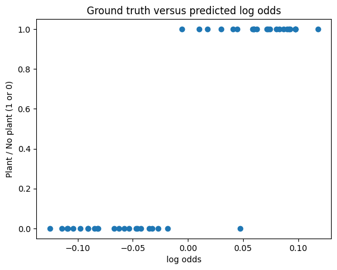

```python
with torch.no_grad():
    plt.scatter(yhat_init_2.numpy(), y_all.numpy())
    plt.title("Ground truth versus predicted log odds")
    plt.xlabel("log odds")
    plt.ylabel("Plant / No plant (1 or 0)")
```

```python
with torch.no_grad():
    print(criterion(yhat_init_2, y_all))
```

```
tensor(0.6606)
```

```python
model_2.to(device)
```

```
Sequential(
  (0): SoftThreshold2(
    (L): ShiftThenScale(10.0)
    (A): MyAbs()
    (S): Sigmoid()
    (R): ReLU()
  )
  (1): RemoveSimultaneous(
    (R): ReLU()
  )
  (2): Integrate(sum_dim=(1, 2, 3)
  (3): Flatten(start_dim=1, end_dim=-1)
  (4): BatchNorm1d(1, eps=1e-05, momentum=0.0, affine=True, track_running_stats=True)
  (5): Flatten(start_dim=0, end_dim=-1)
)
```

```python
optimizer_2 = optim.Adam(model_2.parameters(), lr=1e-1, weight_decay=0.0)
```

```python
outputs, labels = myopt(device, optimizer_2, model_2, criterion, dyn_loader, iter=80)
```

```
100% |#########################################| Time:  0:13:06, loss: 0.370897
```

```python
# with torch.no_grad():
#     print(outputs, labels)
```

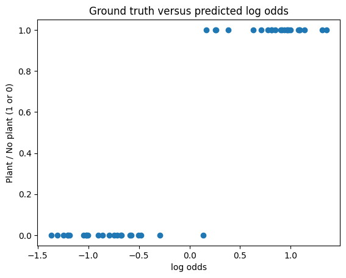

```python
with torch.no_grad():
    plt.scatter(outputs.numpy(), labels.numpy())
    plt.title("Ground truth versus predicted log odds")
    plt.xlabel("log odds")
    plt.ylabel("Plant / No plant (1 or 0)")
```

```python
[(name, theta, theta.grad) for name, theta in model_2.named_parameters()]
```

```
[('0.L.shift',
  Parameter containing:
  tensor(-0.2964, device='cuda:0', requires_grad=True),
  tensor(0.0182, device='cuda:0')),
 ('0.L.scale',
  Parameter containing:
  tensor(-12.0017, device='cuda:0', requires_grad=True),
  tensor(2.5145e-05, device='cuda:0')),
 ('0.A.shift',
  Parameter containing:
  tensor(-3.0548, device='cuda:0', requires_grad=True),
  tensor(4.5884e-07, device='cuda:0')),
 ('0.A.log_half_width',
  Parameter containing:
  tensor(-2.0869, device='cuda:0', requires_grad=True),
  tensor(5.6932e-08, device='cuda:0')),
 ('0.A.log_scale',
  Parameter containing:
  tensor(3.7463, device='cuda:0', requires_grad=True),
  tensor(-8.5860e-08, device='cuda:0')),
 ('4.weight',
  Parameter containing:
  tensor([8.5806], device='cuda:0', requires_grad=True),
  tensor([-0.0274], device='cuda:0')),
 ('4.bias',
  Parameter containing:
  tensor([-0.0011], device='cuda:0', requires_grad=True),
  tensor([0.0008], device='cuda:0'))]
```

```python
# We end up with a pretty narrow band for the standard deviation.
with torch.no_grad():
  cent = model_2._modules['0'].A.shift.cpu().numpy()
  hw = torch.exp(model_2._modules['0'].A.log_half_width).cpu().numpy()
  print("Log var center: {:.2f}, log var half width: {:.2f}, sd low, high: {:.2f}, {:.2f}".format(
      cent, hw, np.exp(0.5*(cent - hw)), np.exp(0.5*(cent + hw))
  ))
```

```
Log var center: -3.05, log var half width: 0.12, sd low, high: 0.20, 0.23
```

## Enforcing sparsity in NPC

Another option for improving model performance is to build into the loss function a penalty for excessive detections in the NPC. We don't just want to separate the two groups, we want to eliminate detections from NPC.

One challenge in doing this is figuring out the correct trade-off between the original criterion and then the "sparsity" we are trying to enforce. Presumably, one could use a reverse-lasso type approach and start with no penalty and then subsequently increase it.

Here the hypothetical output from the model includes the log-odds values as well as the values after the integration step. While we have implemented this approach, we forego that here, since the results above suffice; however, we mention it for the sake of completeness.

```python
# Penalize NPC - finding the right balance is key here
def criterion_with_sparsity(myout, labels, pen=1):
    return criterion(myout[0,:], labels) + 0.69 * pen * torch.mean((1 - labels) * myout[1,:])

# def criterion3(myout, labels):
#     return torch.mean((1 - labels) * myout[1,:]) + torch.mean(labels / myout[1,:])
```

# Conclusion

Herein we have shown that we can formalize the ad hoc method from `analysis-01-dynamics` as a neural network model and learn the optimal set of parameters for this model given data.

The data here consists of only 46 cases, which is sufficient for learning the parameters of our model. However, our approach suggests that by employing a larger dataset we could consider larger models, i.e. a deep neural network to capture more complex patterns distinguishing plants from controls.